# SG_01_FUNDRAISER_ADDR_ZIP

Fundraiser zip · Identifier report

## Overview

**Description**

Foreign Address - Postal code

**Table**

`SG-P01-T01-FUNDRAISERS-INFO` (many)

**Location code**

`SCHED-G-PART-01-LINE-02B-COL-i`

**Family**

`SCHED-G-PART-01-LINE-02B-COL-i` · siblings: SG_01_FUNDRAISER_ADDR_CITY, SG_01_FUNDRAISER_ADDR_CNTR, SG_01_FUNDRAISER_ADDR_L1, SG_01_FUNDRAISER_ADDR_L2, SG_01_FUNDRAISER_ADDR_STATE, SG_01_FUNDRAISER_NAME_INDIV

**Data type**

text (xsd: )

**Scope**

PZ

**Status**

unreviewed

6

xpaths mapped (6 observed)

68,558

filings with a value

2010–2024

tax years observed

4

open flags (1 errors)

## Flags

| Severity | Flag | Xpath | Detail |
| --- | --- | --- | --- |
| ⚠ error | `COLLISION` | IRS990ScheduleG/FundraiserActivityInfoGrp/ForeignAddress/ForeignPostalCd | 409 filings contain 2+ of its xpaths; most common set: /Return/ReturnData/IRS990ScheduleG/FundraiserActivityInfoGrp/ForeignAddress/ForeignPostalCd ; /Return/ReturnData/IRS990ScheduleG/FundraiserActivi… |
| ⓘ info | `MANY_NOT_REPEATING` | IRS990ScheduleG/FundraiserActivityInfoGrp/USAddress/ZIPCd | many-to-one table, but 72% of values sit in no repeating element |
| ⓘ info | `MANY_NOT_REPEATING` | IRS990ScheduleG/FundraiserActivityInformation/AddressUS/ZIPCode | many-to-one table, but 71% of values sit in no repeating element |
| ⓘ info | `MANY_NOT_REPEATING` | IRS990ScheduleG/FundraiserActivityInfoGrp/USAddress/ZIPCode | many-to-one table, but 71% of values sit in no repeating element |

## Xpaths

All mapped xpaths (under /Return/ReturnData or /Return/ReturnHeader), oldest first. Charts label each series by its xpath.

| Xpath | Form | Chart label | First year | Last year | Versions | Filings | Repeats in |
| --- | --- | --- | --- | --- | --- | --- | --- |
| IRS990ScheduleG/FundraiserActivityInformation/AddressUS/ZIPCode | Sched G | …ScheduleG/FundraiserActivityInformation/AddressUS/ZIPCode | 2010 | 2012 | 12 | 9,547 | 28.5% |
| IRS990ScheduleG/FundraiserActivityInformation/AddressForeign/PostalCode | Sched G | …G/FundraiserActivityInformation/AddressForeign/PostalCode | 2010 | 2012 | 9 | 67 | 17.9% |
| IRS990ScheduleG/FundraiserActivityInfoGrp/USAddress/ZIPCode | Sched G | same | 2013 | 2013 | 3 | 4,040 | 27.6% |
| IRS990ScheduleG/FundraiserActivityInfoGrp/ForeignAddress/PostalCode | Sched G | …duleG/FundraiserActivityInfoGrp/ForeignAddress/PostalCode | 2013 | 2013 | 3 | 28 | 10.7% |
| IRS990ScheduleG/FundraiserActivityInfoGrp/USAddress/ZIPCd | Sched G | same | 2014 | 2024 | 34 | 54,332 | 27.1% |
| IRS990ScheduleG/FundraiserActivityInfoGrp/ForeignAddress/ForeignPostalCd | Sched G | …/FundraiserActivityInfoGrp/ForeignAddress/ForeignPostalCd | 2014 | 2024 | 31 | 544 | 17.6% |

## Coverage

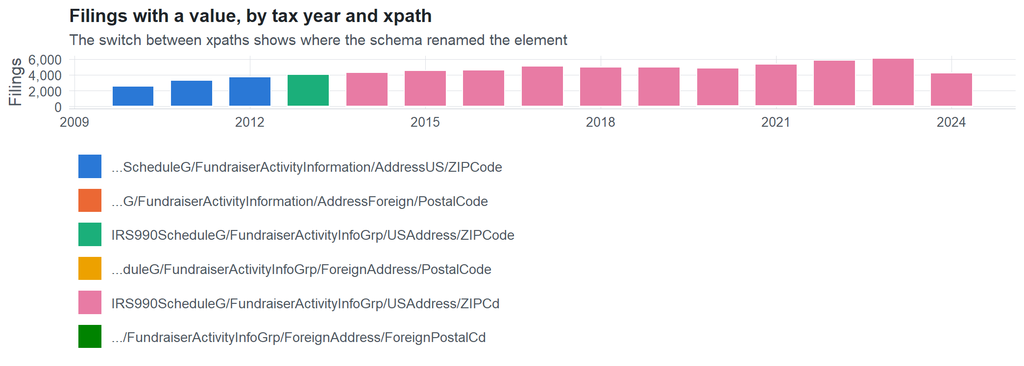

**Table view**

Table view: filings by tax year and series

| Tax year | …ScheduleG/FundraiserActivityInformation/AddressUS/ZIPCode | …G/FundraiserActivityInformation/AddressForeign/PostalCode | IRS990ScheduleG/FundraiserActivityInfoGrp/USAddress/ZIPCode | …duleG/FundraiserActivityInfoGrp/ForeignAddress/PostalCode | IRS990ScheduleG/FundraiserActivityInfoGrp/USAddress/ZIPCd | …/FundraiserActivityInfoGrp/ForeignAddress/ForeignPostalCd |
| --- | --- | --- | --- | --- | --- | --- |
| 2010 | 2,546 | 21 | 0 | 0 | 0 | 0 |
| 2011 | 3,261 | 21 | 0 | 0 | 0 | 0 |
| 2012 | 3,740 | 25 | 0 | 0 | 0 | 0 |
| 2013 | 0 | 0 | 4,040 | 28 | 0 | 0 |
| 2014 | 0 | 0 | 0 | 0 | 4,268 | 35 |
| 2015 | 0 | 0 | 0 | 0 | 4,502 | 34 |
| 2016 | 0 | 0 | 0 | 0 | 4,586 | 37 |
| 2017 | 0 | 0 | 0 | 0 | 5,043 | 38 |
| 2018 | 0 | 0 | 0 | 0 | 4,932 | 35 |
| 2019 | 0 | 0 | 0 | 0 | 4,909 | 42 |
| 2020 | 0 | 0 | 0 | 0 | 4,794 | 50 |
| 2021 | 0 | 0 | 0 | 0 | 5,278 | 63 |
| 2022 | 0 | 0 | 0 | 0 | 5,772 | 85 |
| 2023 | 0 | 0 | 0 | 0 | 6,040 | 78 |
| 2024 | 0 | 0 | 0 | 0 | 4,208 | 47 |

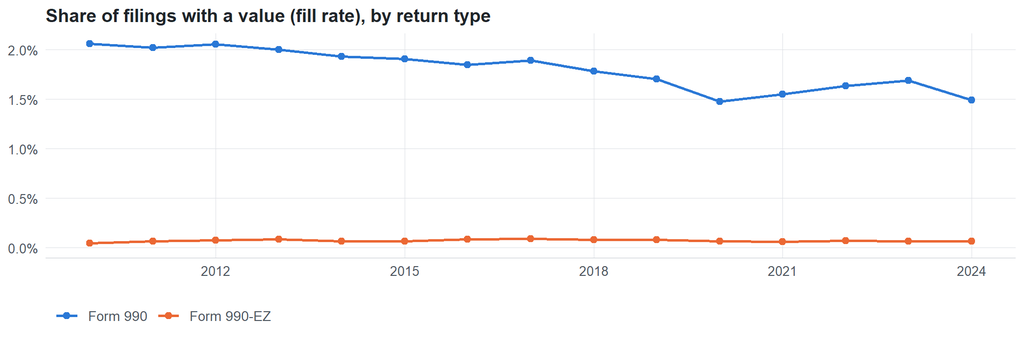

**Table view**

Table view: fill rate

| Tax year | Return type | Filings | All filings | Fill rate |
| --- | --- | --- | --- | --- |
| 2010 | Form 990 | 2,537 | 123,025 | 2.06% |
| 2010 | Form 990-EZ | 30 | 63,326 | 0.05% |
| 2011 | Form 990 | 3,227 | 159,504 | 2.02% |
| 2011 | Form 990-EZ | 55 | 82,048 | 0.07% |
| 2012 | Form 990 | 3,694 | 179,688 | 2.06% |
| 2012 | Form 990-EZ | 71 | 93,750 | 0.08% |
| 2013 | Form 990 | 3,979 | 198,855 | 2.00% |
| 2013 | Form 990-EZ | 89 | 104,375 | 0.09% |
| 2014 | Form 990 | 4,226 | 218,619 | 1.93% |
| 2014 | Form 990-EZ | 77 | 116,417 | 0.07% |
| 2015 | Form 990 | 4,455 | 233,519 | 1.91% |
| 2015 | Form 990-EZ | 81 | 124,894 | 0.06% |
| 2016 | Form 990 | 4,511 | 243,903 | 1.85% |
| 2016 | Form 990-EZ | 112 | 130,484 | 0.09% |
| 2017 | Form 990 | 4,954 | 261,612 | 1.89% |
| 2017 | Form 990-EZ | 127 | 139,144 | 0.09% |
| 2018 | Form 990 | 4,846 | 271,442 | 1.79% |
| 2018 | Form 990-EZ | 121 | 149,384 | 0.08% |
| 2019 | Form 990 | 4,832 | 283,694 | 1.70% |
| 2019 | Form 990-EZ | 119 | 152,622 | 0.08% |
| 2020 | Form 990 | 4,733 | 320,342 | 1.48% |
| 2020 | Form 990-EZ | 111 | 169,864 | 0.07% |
| 2021 | Form 990 | 5,216 | 336,480 | 1.55% |
| 2021 | Form 990-EZ | 125 | 202,724 | 0.06% |
| 2022 | Form 990 | 5,708 | 349,055 | 1.64% |
| 2022 | Form 990-EZ | 149 | 206,130 | 0.07% |
| 2023 | Form 990 | 5,988 | 354,768 | 1.69% |
| 2023 | Form 990-EZ | 130 | 206,379 | 0.06% |
| 2024 | Form 990 | 4,139 | 277,298 | 1.49% |
| 2024 | Form 990-EZ | 116 | 178,867 | 0.06% |

## Repeating groups

Table cardinality in the concordance: **many**. 6 of 6 observed xpaths repeat within a filing.

Repeating element each xpath was observed in (from the raw indexed xpath)

| Xpath | Repeating element | Filings (summed over years) |
| --- | --- | --- |
| IRS990ScheduleG/FundraiserActivityInformation/AddressForeign/PostalCode | (none) | 22 |
| IRS990ScheduleG/FundraiserActivityInformation/AddressForeign/PostalCode | IRS990ScheduleG/FundraiserActivityInformation | 45 |
| IRS990ScheduleG/FundraiserActivityInformation/AddressUS/ZIPCode | (none) | 6758 |
| IRS990ScheduleG/FundraiserActivityInformation/AddressUS/ZIPCode | IRS990ScheduleG/FundraiserActivityInformation | 2789 |
| IRS990ScheduleG/FundraiserActivityInfoGrp/ForeignAddress/PostalCode | (none) | 12 |
| IRS990ScheduleG/FundraiserActivityInfoGrp/ForeignAddress/PostalCode | IRS990ScheduleG/FundraiserActivityInfoGrp | 16 |
| IRS990ScheduleG/FundraiserActivityInfoGrp/USAddress/ZIPCode | (none) | 2886 |
| IRS990ScheduleG/FundraiserActivityInfoGrp/USAddress/ZIPCode | IRS990ScheduleG/FundraiserActivityInfoGrp | 1154 |
| IRS990ScheduleG/FundraiserActivityInfoGrp/ForeignAddress/ForeignPostalCd | (none) | 157 |
| IRS990ScheduleG/FundraiserActivityInfoGrp/ForeignAddress/ForeignPostalCd | IRS990ScheduleG/FundraiserActivityInfoGrp | 387 |
| IRS990ScheduleG/FundraiserActivityInfoGrp/USAddress/ZIPCd | (none) | 39016 |
| IRS990ScheduleG/FundraiserActivityInfoGrp/USAddress/ZIPCd | IRS990ScheduleG/FundraiserActivityInfoGrp | 15316 |

## Values

| Result | Check | Detail |
| --- | --- | --- |
| ✓ pass | Values have the ZIP format | 99.3% of values match ^(99999\|999999999\|99999-9999)$ |
| ✓ pass | Stored as text | data type is text |
| ✓ pass | No placeholder values | no all-zero / all-nine placeholders among the most common values |
| ⓘ info | Leading zeros present | at least 1% of values start with 0 in some year, so numeric storage would change them |

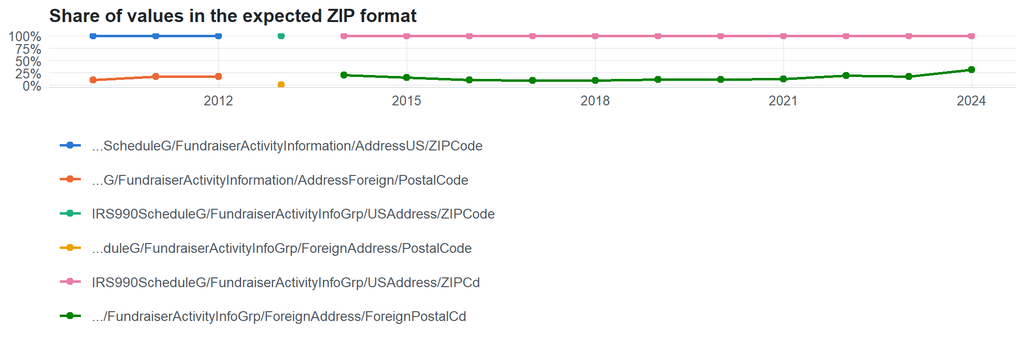

Value shapes (9 = digit, A = letter)

| Series | Shape | Expected | Filings |
| --- | --- | --- | --- |
| …ScheduleG/FundraiserActivityInformation/AddressUS/ZIPCode | 99999 | yes | 9,172 |
| …ScheduleG/FundraiserActivityInformation/AddressUS/ZIPCode | 999999999 | yes | 590 |
| …G/FundraiserActivityInformation/AddressForeign/PostalCode | A9A 9A9 | no | 37 |
| …G/FundraiserActivityInformation/AddressForeign/PostalCode | 99999 | yes | 9 |
| …G/FundraiserActivityInformation/AddressForeign/PostalCode | A9A9A9 | no | 3 |
| …G/FundraiserActivityInformation/AddressForeign/PostalCode | 9999 | no | 3 |
| …G/FundraiserActivityInformation/AddressForeign/PostalCode | A99 9A9 | no | 2 |
| …G/FundraiserActivityInformation/AddressForeign/PostalCode | AA99 9AA | no | 2 |
| …G/FundraiserActivityInformation/AddressForeign/PostalCode | A9A 9AA | no | 1 |
| …G/FundraiserActivityInformation/AddressForeign/PostalCode | 99A9A9 | no | 1 |
| …G/FundraiserActivityInformation/AddressForeign/PostalCode | A-9999 | no | 1 |
| IRS990ScheduleG/FundraiserActivityInfoGrp/USAddress/ZIPCode | 99999 | yes | 3,902 |
| IRS990ScheduleG/FundraiserActivityInfoGrp/USAddress/ZIPCode | 999999999 | yes | 214 |
| …duleG/FundraiserActivityInfoGrp/ForeignAddress/PostalCode | A9A 9A9 | no | 13 |
| …duleG/FundraiserActivityInfoGrp/ForeignAddress/PostalCode | 9999 | no | 3 |
| …duleG/FundraiserActivityInfoGrp/ForeignAddress/PostalCode | A99 9A9 | no | 2 |
| …duleG/FundraiserActivityInfoGrp/ForeignAddress/PostalCode | A9A 9AA | no | 2 |
| …duleG/FundraiserActivityInfoGrp/ForeignAddress/PostalCode | A9A9A9 | no | 2 |
| IRS990ScheduleG/FundraiserActivityInfoGrp/USAddress/ZIPCd | 99999 | yes | 53,082 |
| IRS990ScheduleG/FundraiserActivityInfoGrp/USAddress/ZIPCd | 999999999 | yes | 2,113 |
| …/FundraiserActivityInfoGrp/ForeignAddress/ForeignPostalCd | A9A 9A9 | no | 235 |
| …/FundraiserActivityInfoGrp/ForeignAddress/ForeignPostalCd | 99999 | yes | 70 |
| …/FundraiserActivityInfoGrp/ForeignAddress/ForeignPostalCd | A9A9A9 | no | 55 |
| …/FundraiserActivityInfoGrp/ForeignAddress/ForeignPostalCd | 9999 | no | 40 |
| …/FundraiserActivityInfoGrp/ForeignAddress/ForeignPostalCd | 9999999 | no | 34 |
| …/FundraiserActivityInfoGrp/ForeignAddress/ForeignPostalCd | AA99 9AA | no | 15 |
| …/FundraiserActivityInfoGrp/ForeignAddress/ForeignPostalCd | A99 9A9 | no | 5 |

## Examples

| Tax year | Return | Xpath | Organization | Value | Source |
| --- | --- | --- | --- | --- | --- |
| 2024 | 990 | IRS990ScheduleG/FundraiserActivityInfoGrp/ForeignAddress/ForeignPostalCd | COOPERATIVE FOR ASSISTANCE AND RELIEF | M3B 2T6 | [XML](https://gt990datalake-rawdata.s3.amazonaws.com/EfileData/XmlFiles/202523579349300712_public.xml) |
| 2024 | 990 | IRS990ScheduleG/FundraiserActivityInfoGrp/USAddress/ZIPCd | PORTLAND PARKS FOUNDATION | 972322853 | [XML](https://gt990datalake-rawdata.s3.amazonaws.com/EfileData/XmlFiles/202600919349301400_public.xml) |
| 2023 | 990 | IRS990ScheduleG/FundraiserActivityInfoGrp/ForeignAddress/ForeignPostalCd | INTERNATIONAL CITYCOUNTY MANAGEMENT | P600-1111 | [XML](https://gt990datalake-rawdata.s3.amazonaws.com/EfileData/XmlFiles/202531349349305838_public.xml) |
| 2023 | 990 | IRS990ScheduleG/FundraiserActivityInfoGrp/USAddress/ZIPCd | RINGLING COLLEGE OF ART AND DESIGN INC | 55431 | [XML](https://gt990datalake-rawdata.s3.amazonaws.com/EfileData/XmlFiles/202501049349302265_public.xml) |
| 2022 | 990 | IRS990ScheduleG/FundraiserActivityInfoGrp/ForeignAddress/ForeignPostalCd | THE NATURE CONSERVANCY | M2N 7E9 | [XML](https://gt990datalake-rawdata.s3.amazonaws.com/EfileData/XmlFiles/202431279349301813_public.xml) |
| 2022 | 990 | IRS990ScheduleG/FundraiserActivityInfoGrp/USAddress/ZIPCd | PHOENIX COMMUNITY ALLIANCE | 85003 | [XML](https://gt990datalake-rawdata.s3.amazonaws.com/EfileData/XmlFiles/202303199349316930_public.xml) |
| 2021 | 990 | IRS990ScheduleG/FundraiserActivityInfoGrp/ForeignAddress/ForeignPostalCd | TIDES CENTER | 94530 | [XML](https://gt990datalake-rawdata.s3.amazonaws.com/EfileData/XmlFiles/202203189349311670_public.xml) |
| 2021 | 990 | IRS990ScheduleG/FundraiserActivityInfoGrp/USAddress/ZIPCd | HOUSTON HUMANE SOCIETY | 68526 | [XML](https://gt990datalake-rawdata.s3.amazonaws.com/EfileData/XmlFiles/202223159349306577_public.xml) |
| 2020 | 990 | IRS990ScheduleG/FundraiserActivityInfoGrp/ForeignAddress/ForeignPostalCd | NATIONAL AUDUBON SOCIETY INC | L1T 4W6 | [XML](https://gt990datalake-rawdata.s3.amazonaws.com/EfileData/XmlFiles/202230669349301318_public.xml) |
| 2020 | 990 | IRS990ScheduleG/FundraiserActivityInfoGrp/USAddress/ZIPCd | National Redistricting Action Fund | 20003 | [XML](https://gt990datalake-rawdata.s3.amazonaws.com/EfileData/XmlFiles/202221369349307752_public.xml) |
| 2019 | 990 | IRS990ScheduleG/FundraiserActivityInfoGrp/ForeignAddress/ForeignPostalCd | OREGON PUBLIC BROADCASTING | M6K3C5 | [XML](https://gt990datalake-rawdata.s3.amazonaws.com/EfileData/XmlFiles/202110419349300526_public.xml) |
| 2019 | 990 | IRS990ScheduleG/FundraiserActivityInfoGrp/USAddress/ZIPCd | CEDARS-SINAI MEDICAL CENTER | 90036 | [XML](https://gt990datalake-rawdata.s3.amazonaws.com/EfileData/XmlFiles/202131349349305998_public.xml) |

## Reviewer checklist

- The definition matches the form line and instructions for every xpath’s schema years.
- Every xpath pooled here measures the same thing on the 990 and 990-EZ (close enough for analysis).
- The coverage chart has no unexplained gaps or jumps between tax years.
- Each open flag is fixed, or accepted with a note in validation_log.csv.
- The data type is text so leading zeros and letters survive.
- The identifier belongs to the entity the variable names (the filer, preparer, related organization…).
- Formats with and without punctuation (e.g. ZIP+4, dashes) are normalized consistently downstream.

Record the review as a row in `inst/extdata/src/validation_log.csv` (variable_name, reviewer, date, status, note). Evidence built 2026-09-23 17:09:04 MST from the ef2 DuckDB builds (tax years 2009–2024).